# An algorithm for a spatial mapping using a hexagon tilegram, with application to Australia disease maps

Stephanie Kobakian https://github.com/srkobakian (Queensland University of Technology)  
2019-03-04

# Abstract

# Introduction

## Motivation

Spatial distributions of people and human related statistics are not well presented in geographic maps. Populations congregate around major cities and the lack of land available encourages vertical living. Government bodies define localities, attempting to evenly distribute the population into measureable areas. As the rural areas of Australia are often sparsely populated in comparison to their urban centres the square meterage of the geographic areas may vastly differ in size.

Alternative mapping methods allow increased understanding of the spatial distribution of a variable amongst the population. Allowing the focus to be placed on the distribution of the statistics between the groups of areas, not the geography.

Extremely small geographic areas are lost on large geographic maps, areas in Sydney or Melbourne are not easily compared at a high level. Cartograms allow an alternative view. Placingimportance on the statistic of interest, allowing unequal map space on the display to represent differences in the statistic. These maps rely on the statistic of interest to determine the layout, and often fail to preserve a recognisable view of Australia. Tile grams allow a better preservation of relationships. Decrease the emphasis on the amount of geograhic area considered to be interesting. Focus on the relationship between neighbours, in considering aggregated statistics of heterogeneous regions.

Australia and Canada present an application that contains an unusual population settlement and dispersion over the geographical space: - Australia: Dense south east, sparse central and west

## Background

- Choropleth methods are accurate geographically.
- Cartogram alternative map has been used historically.
- Spatial relationships are preserved.

## Proposed Solution

- Like Dorling, same shape will be used. Like tilegram, tessellation using equally sized shapes.
- Allocate each geographic area to a map space of consistent tessellated shape

which is different from existing algorithms: - contiguous, keeps exact neighbours, no recognisable shape - non contiguous, keeps shape, can lose neighbours

- Clear to see spatial distribution, _ Should keep neighbours relationships intact as geographic neighbours will have similar values

Easier to read distribution at a distance, see a much larger area, general relationship at a glance

Works well for America, states are almost homogeneous Works well for England, London is the biggest issue, pushing out rural areas does not disturb population dense areas.

Our solution considers multiple population dense areas.

Allows dispersion to be increased when needed, and distance from origin to be considered

The Dorling maps in [@TVSSS] give examples of displacing central geographically small, population dense areas. This inspired the concept of this algorithm.

# Algorithm

The algorithm operates on a set of polygons. There are parameters used in the process that may be provided, or will be automatically derived. All necessary functions are exported, with a main function `create_hexmap` used to step through automatically.

## Parameters

As the `create_hexmap` function requires several parameters, if they are not provided, the information will be derived from the polygon set used.

**The following must be provided to `create_hexmap`:**

| parameter | description |
| --- | --- |
| shp | an Rdata object containing the polygon information |
| shp_path | character string location of the shape file that contains the polygon information |
| sf_id | name of a unique column that distinguishes areas |
| capital_cities | a data frame of reference locations when allocating hexagons, capital cities of Australia are provided as capital_cities |

The polygon set of Local Government Areas in Australia in 2016 is stored in the sugarbag package data as `tas_lga`. To create this object:

```
# Download resource
# link to folder containing .shp file on sugarbag site.

aus_sa2 <- read_shape("file location")
```

A column of the data set must be used as a unique identifier of areas.

**The following will be determined within `create_hexmap` if not provided. They are created throughout the following example:**

| parameter | description |
| --- | --- |
| projstring | a string to indicate the projection and epsg |
| epsg | the four character string to indicate the CRS |
| buffer_dist | a float value for distance in degrees to extend beyond the - geometry provided |
| hex_size | a float value in degrees for the diameter of the hexagons |
| hex_filter | amount of hexagons around centroid to consider for allocation |
| width | the angle used to filter the grid points around a centroid |

When utilising individual `sugarbag` functions, we recommend the following approach:

## Polygon Information

Begin with a set of polygons. There are several ways of providing the set of polygons. The following methods are available via the `read_shape` function. It utilises the `st_read` function is to create the sf object.

- If the shape file is an .Rda file, it is loaded into the current environment.
- To utilise a custom shape file from a directory on your device, provide the file path for .shp file.

Empty geometries are removed from the sf object, and the remaining polygons are projected to the Australian standard using `projstring`.

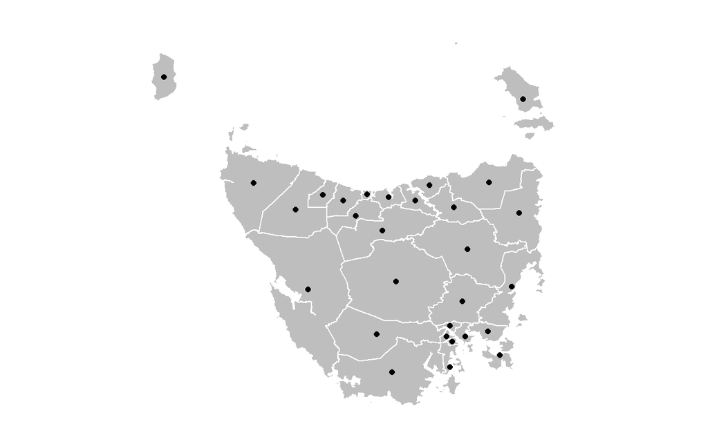

Figure 1: lga Local Government Areas and derived centroids.

## Hexagon grid

Create a grid of hexagon centroids using the `create_grid` function.

The grid creation takes several steps. It requires the centroids, the bounding box, the hexagon size and the buffer distance.

### Step 1: Expand the grid

Two sequences are used, one for longitude and another for latitude. The sequences begin at the minimum longitude or latitude, minus the buffer distance. Equally spaced intervals, the size of the hexagons, are created up to the maximum longitude or latitude, plus the buffer distance.

An individual point is created from all combinations of longitude and latitude sequences.

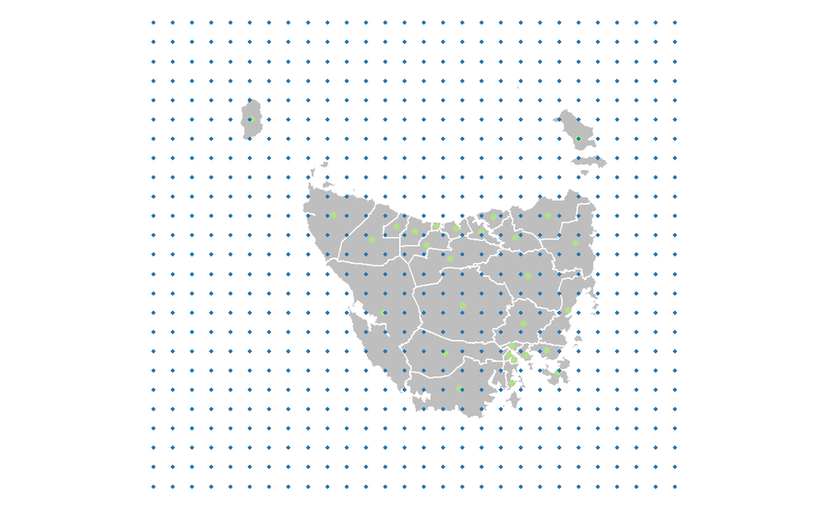

This grid is square, which will not facilitate tessellated hexagons. Every second latitude (row) of points will be shifted right by half of the hexagon size.

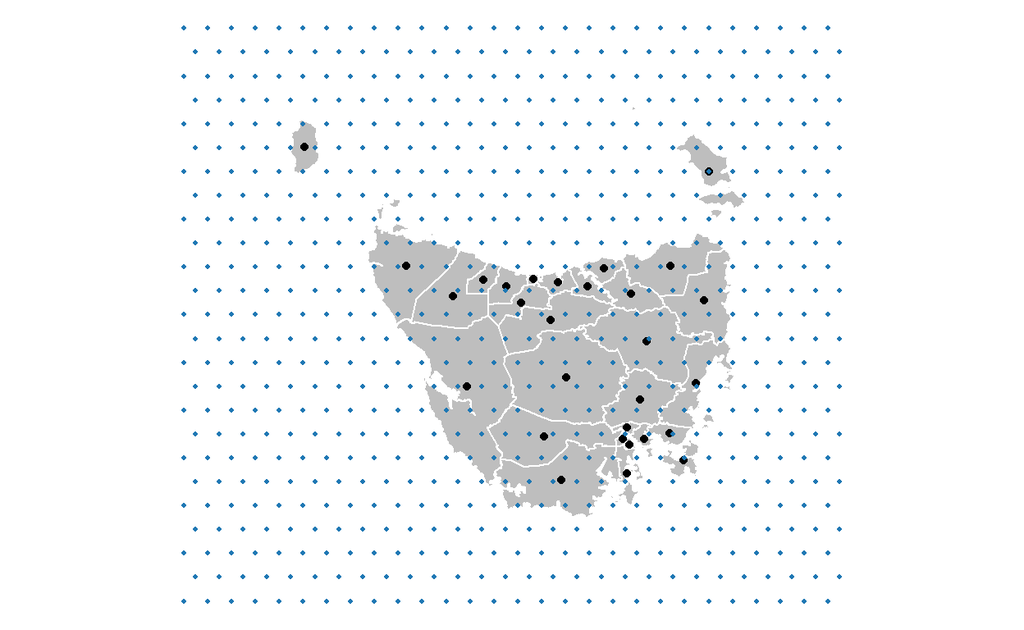

Each row and column is given an ID

There are more points than necessary on this grid.

### Step 2: Rolling windows

To filter the grid for appropriate hexagons for allocation, the `create_buffer` function is called from `create_grid`.

It finds the amount of columns and rows needed to capture the set of centroids.

The rows and columns are divided into 20 groups. The amount of rows in each latitude group and the amount of columns in each longitude group are then used as the width of manual rolling windows.

The first rolling window function finds the minimum and maximum centroid values for the groups of longitude columns and the groups of latitude rows. The specific rows and columns in the rolling windows are defined.

The second rolling window function finds the average of the rolling minimum and rolling maximum centroid values, for the longitude columns and latitude rows.

### Step 3: Filtering the grid

Only the grid points between the rolling average of the minimum and maximum centroid values are kept, for each row and column of the grid.

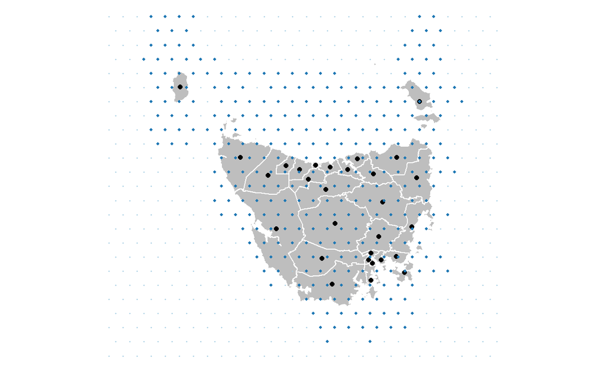

## Centroid to focal point distance

For each polygon centroid in the set. Find the distance to each of the focal points provided. The closest focal point name, the distance to the polygon centroid, and the angle from focal point to polygon centroid will be returned and added to the polygon data set in the polygon centroid row.

The distance between the polygon centroid and it’s closest focal point data set is used to arrange the data set for allocation. The points are arranged in ascending order, from the centroid closest to any of the focal points, to the furthest.

## Allocation of centroids

Define a distance around a centroid to consider for possible hexagon location.

Allocate each centroid, beginning with the closest to a focal point, extending to the furthest. Will preserve spatial relationship.

Allocation of all centroids can now take place using the set of polygon centroids and the hexagon map grid. For each polygon centroid, only the hexagon grid points that have not yet been used can be considered.

The filter distance parameter is used to subset possible grid points to only those surrounding the polygon centroid within the filter distance.

The following example considers one of the Local Government Areas. These steps are repeated for each polygon.

### Step 1: Filter the grid for unassigned hexagon points

Keep only the available hexagon points, this will prevent multiple areas being allocated to the same hexagon.

### Step 2: Filter the grid points for those closest to the centroid

This will allow only the closest points, that are not assigned, to be considered.

Create a box filter

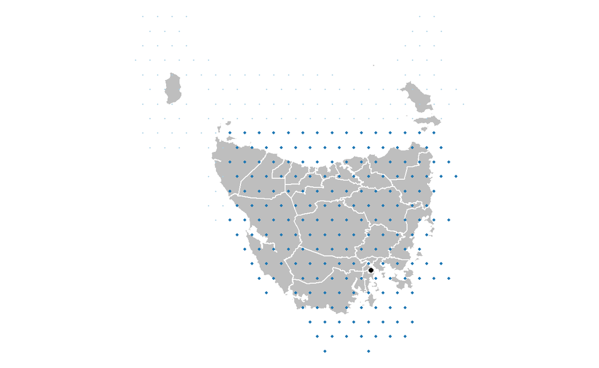

Create circle filter

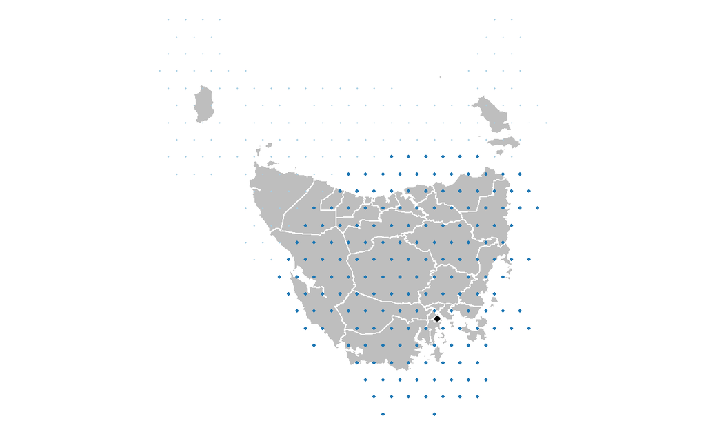

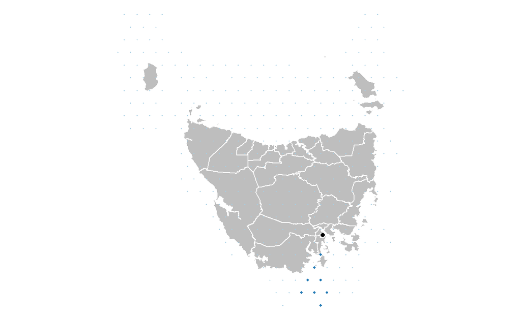

Using the angle between each polygon centroid, and it’s the closest focal point, the subset of points is filtered again. Of these possible points, only those within a specific amount of degrees plus and minus a specific angle range are kept. This angle begins at 30 degrees by default, and may increase if necessary.

If no available hexagon grid point is found within the original filter distance and angle, the distance is expanded, only when a maximum distance is reached will the angle expand to accommodate more possible grid points.

The allocation is returned and combined with the data relating to each polygon.

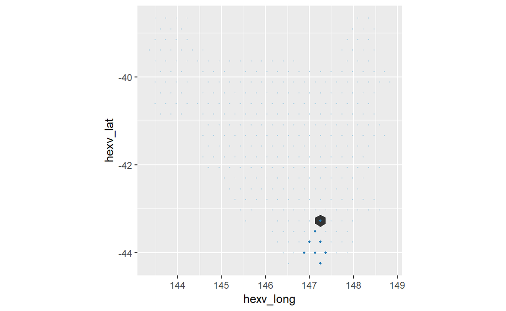

[output not shown]

[output cut: 22 more lines]

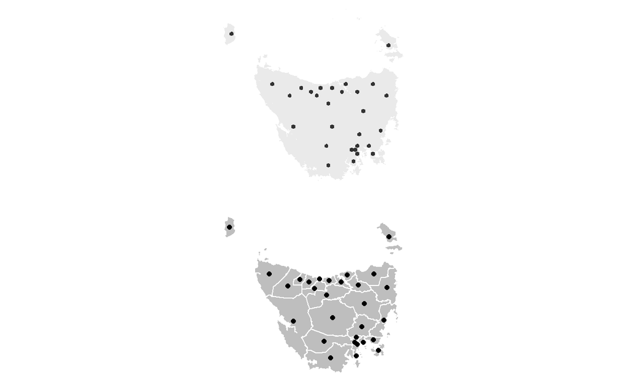

## Applications of algorithm

Examples of Melbourne, lga, Australia At different levels, distance from original centroids, change in area

LGA of all Australia SA2 for lga

# Evaluation

Measure changes to areas: Each hexagon area in the set of $npolys$ is standardised to 1 unit. Where 1 unit is the area of a hexagon of the designated size.

$area_{h_i} = 1$

$area_h = 1 * npolys$

$y_i$ denotes the statistic of interest for polygon i, where i = 1,…,npolygs $x_i$ denotes the spatial area for polygon i, where i = 1,…,npolys

Areal Statistic Distortion is the change in the areal distribution of the set of polygons. Difference between space taken by polygons and space taken by hexagons, with respect to the desired statistic. Setting the desired statistic to area gives the change in map space used to represent the polygons.

The average when considering area used to display:

$A = \sum_{i=1}^{npolys}y_ix_i/ \sum_{i=1}^{npolys}x_i$

$H = \sum_{i=1}^{npolys}y_i/npolys$

Using $w_i = x_i/\sum_{i=1}^{npolys}x_i$

$\sqrt{ 1/npolys\sum_{i=1}^{npolys}(y_i - \bar y)^2 w_i }$

Considering only a local area distortion: Where the subset used contains only neighbours within a certain distance of the polygon centroid

Where $\bar y_d$ is the average of the polygon statistics considering only the polygons where the distance between polygon centroid x_i and polygon centroid x_p is less than d:

$d(x_ix_p) < d$

$\sqrt{ 1/npolys\sum_{i=1}^{npolys}(y_i - \bar y_d)^2 w_i }$

Old neighbours over new neighbours?